# NYCFlights: Arrival Delay Regression Model (Open Ended Variation)

Ryan Guzalowski

4/18/2017

# NYCFlights Model

Using the rectangular data that you created last week create a model for `arr_delay`. Follow a well defined process for creating a model as discussed in class or from one of the readings.

Break the process down into steps and create a codeblock for each step. - Use as many steps you feel as necessary - Concisely explain each step - Show all work

## Step 1: Data Import

```r
# data.frame / dplyr
flights  <- "data/flights.csv" %>% read_csv
# flights <- "data/flights.csv" %>% read.csv(stringsAsFactors=FALSE)
planes   <- read_csv("data/planes.csv")
airports <- read_csv("data/airports.csv")
weather  <- read_csv("data/weather.csv")
# data.tables
flightsDT  <- fread("data/flights.csv")
planesDT   <- fread("data/planes.csv")  %>% setkey(tailnum)
airportsDT <- fread("data/airports.csv")  %>% setkey(faa)
weatherDT  <- fread("data/weather.csv") %>%   setkey(origin,year,month,day,hour)

# BEST:
YX <- flightsDT
YX %<>% merge( planesDT, all.x = TRUE, by='tailnum', suffixes=c('','.pl') )
YX %<>% merge( weatherDT, all.x = TRUE, by=c('origin','year','month','day','hour'), suffixes=c('','.we') )
YX %<>% merge( airportsDT, all.x = TRUE, by.x='origin', by.y='faa', suffixes=c('','.orig') )
YX %<>% merge( airportsDT, all.x = TRUE, by.x='dest', by.y='faa', suffixes=c('','.dest') )
```

## Step 2: Taking a sample of the data

full dataset is too large to work with so here I take a random sample

```r
inds1 <- sample(1:nrow(YX), 1000)

resp <- YX$arr_delay
respS <- resp[inds1]

vars <- YX[, c("arr_delay", "dep_delay", "wind_speed", "wind_gust", "visib")]
varsS <- vars[inds1]
```

# Step 3: Exploratory Data Analysis

looking for simple correlations between datasets

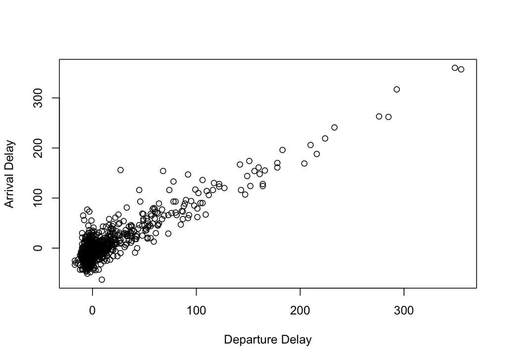

```r
plot(varsS$dep_delay, respS,
     xlab = "Departure Delay", ylab = "Arrival Delay")
```

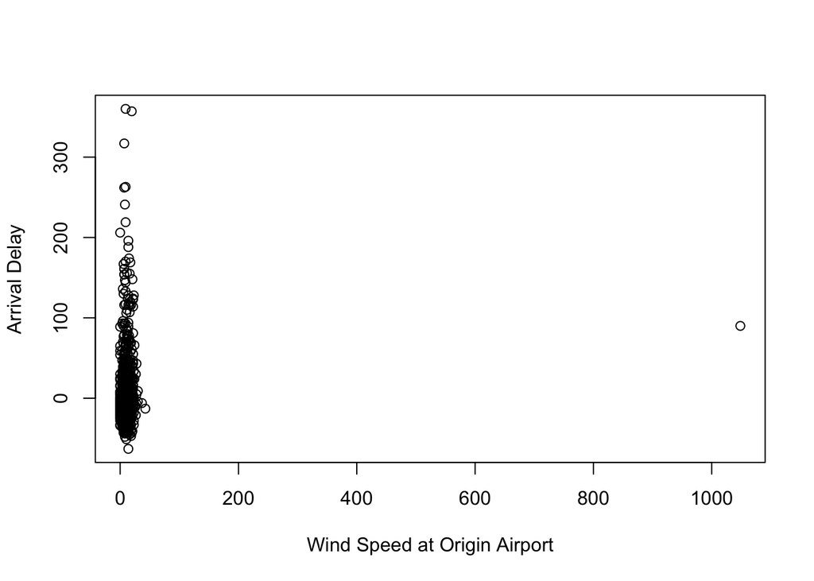

```r
plot(varsS$wind_speed, respS,
     xlab = "Wind Speed at Origin Airport", ylab = "Arrival Delay")
```

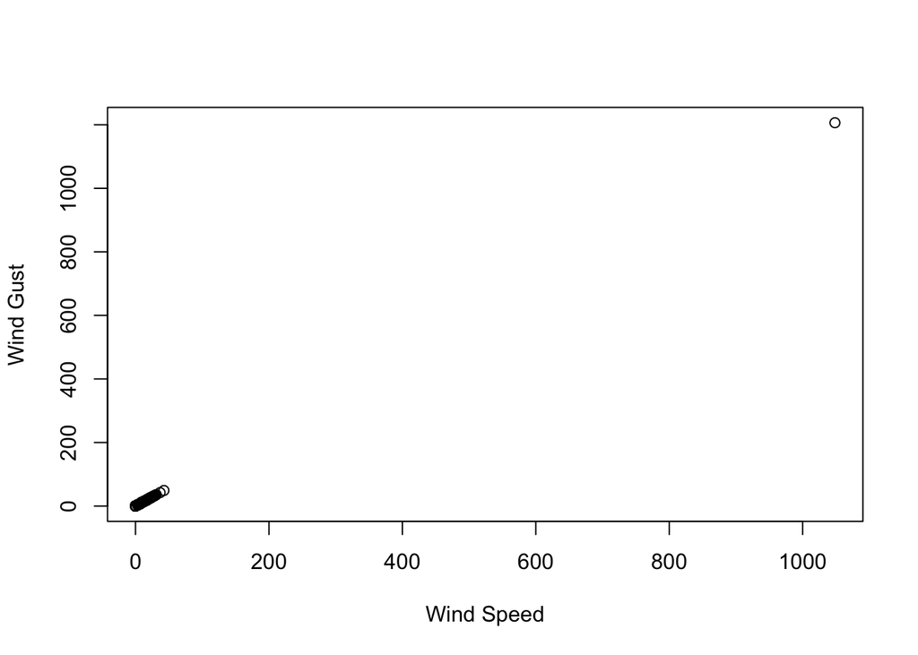

```r
plot(varsS$wind_speed, varsS$wind_gust,
     xlab = "Wind Speed", ylab = "Wind Gust")
```

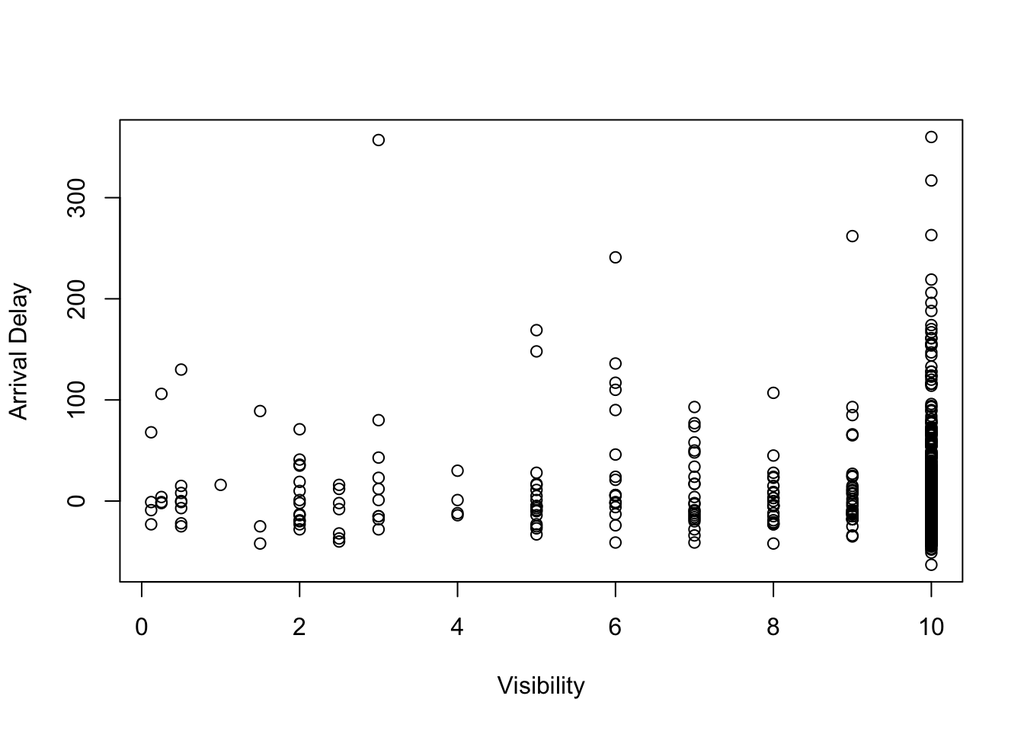

```r
plot(varsS$visib, respS,
     xlab = "Visibility", ylab = "Arrival Delay")
```

# Step 4: Feature Generation

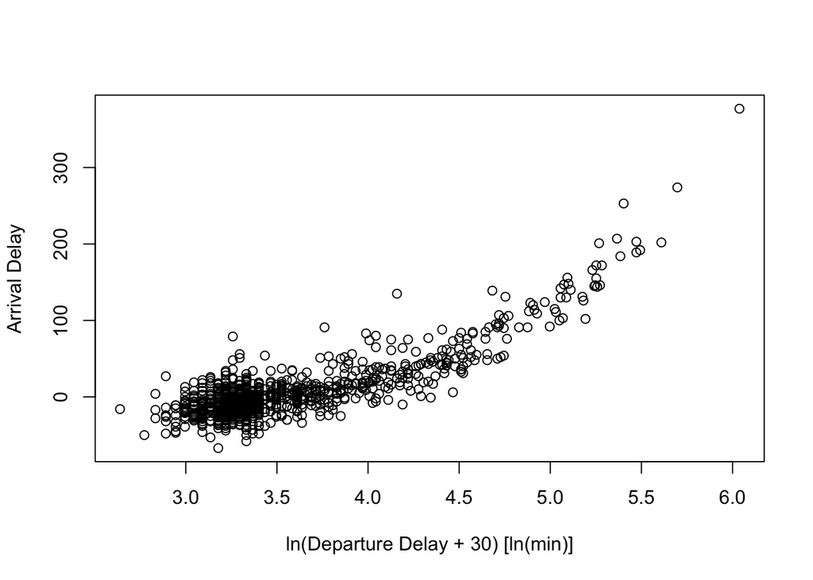

```r
inds2 <- sample(1:nrow(vars), 1000)

respS <- resp[inds2]
predS <- vars$dep_delay[inds2]

notNA <- !is.na(respS) & !is.na(predS)
respS <- respS[notNA]
predS <- predS[notNA]

#added 30 to handle negative values with log transf. Almost all flights will not leave more than 30 min early
predSln <- log(predS+30)

plot(predSln, respS,
     xlab = "ln(Departure Delay + 30) [ln(min)]", ylab = "Arrival Delay")
```

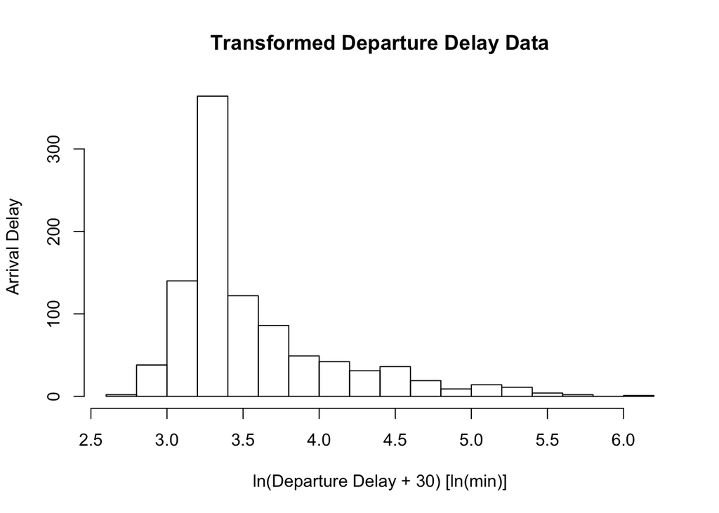

```r
hist(predSln, breaks = 20,
     main = "Transformed Departure Delay Data",
     xlab = "ln(Departure Delay + 30) [ln(min)]", ylab = "Arrival Delay")
```

# Step 5: Train Model

For the naive model, I will use the mean of arrival delay. For the better model, I will fit a quadratic poly regression.

Naive model has RMSE of 41, while quadratic fit has a RMSE of 18.

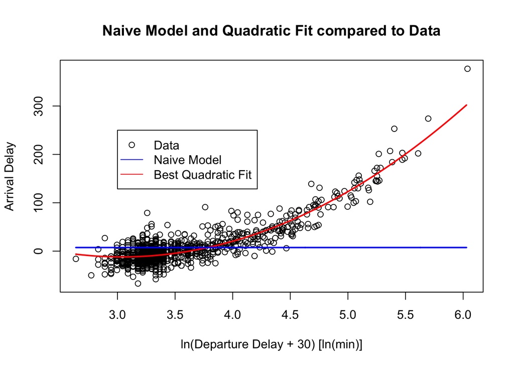

```r
#naive model
aveResp <- mean(respS, na.rm=TRUE)
naiveM <- rep(1,length(respS))*aveResp
naiveRMSE <- sqrt(mean((naiveM-respS)^2))


#quadratic fit
y = respS
x = predSln

model <- lm(y ~ poly(x, 2, raw=TRUE))
xx = seq(min(predSln), max(predSln), .01)
yy <- predict(model, data.frame(x=xx))
yhat <- predict(model, data.frame(x=x))

modelRMSE <- sqrt(mean((yhat-y)^2))

plot(predSln, respS,
     xlab = "ln(Departure Delay + 30) [ln(min)]",
     ylab = "Arrival Delay",
     main = "Naive Model and Quadratic Fit compared to Data")
lines(xx, yy, col = "red", lwd=2)
lines(xx, aveResp*rep(1,length(xx)), col = "blue", lwd=2)
legend(3,250, c("Data", "Naive Model", "Best Quadratic Fit"),
       pch=c(1,NA,NA), lty=c(NA,1,1), col = c("black", "blue", "red"))
```

# Step 6: Validate Model

Here i look at my model with a new random sample of data. RMSE of sample of new data is 19. Increased slightly but still a vast improvement over naive model.

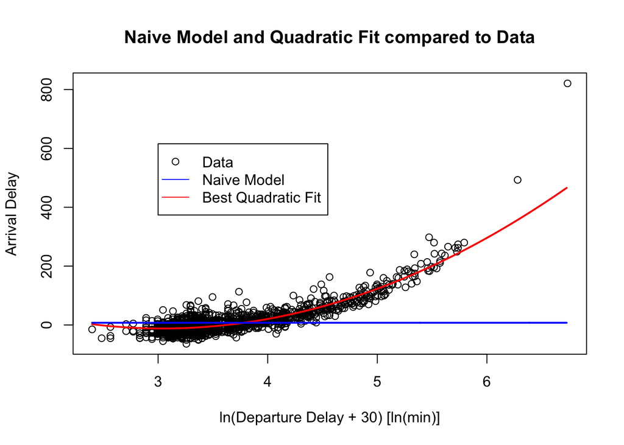

```r
inds3 <- sample(1:nrow(vars), 2000)

respV <- resp[inds3]
predVln <- log(vars$dep_delay[inds3]+30)
notNA <- !is.na(respV) & !is.na(predVln)
respV <- respV[notNA]
predVln <- predVln[notNA]


x <- predVln
y <- respV
xx = seq(min(predVln), max(predVln), .01)
yy <- predict(model, data.frame(x=xx))
yhat <- predict(model, data.frame(x=x))
validateRMSE <- sqrt(mean((yhat-y)^2))

plot(predVln, respV,
     xlab = "ln(Departure Delay + 30) [ln(min)]",
     ylab = "Arrival Delay",
     main = "Naive Model and Quadratic Fit compared to Data")
lines(xx, yy, col = "red", lwd=2)
lines(xx, aveResp*rep(1,length(xx)), col = "blue", lwd=2)
legend(3,max(y)*.75, c("Data", "Naive Model", "Best Quadratic Fit"),
       pch=c(1,NA,NA), lty=c(NA,1,1), col = c("black", "blue", "red"))
```

# Question:

Final model:

This model provides a ~50% improvement over the naive model when comparing RMSE values. The model breaks down at the extremes of arrival delay. It predicts that arrival delay will increase with decreasing departure delay at the extreme of smallest departure delays, which does not make intuitive sense. Additionaly, it underpredicts arrival delay at the other extreme of the largest departure delays in the data.

```r
summary(model)
```

```
##
## Call:
## lm(formula = y ~ poly(x, 2, raw = TRUE))
##
## Residuals:
##     Min      1Q  Median      3Q     Max
## -55.747 -11.080  -0.709   9.184 102.900
##
## Coefficients:
##                         Estimate Std. Error t value Pr(>|t|)
## (Intercept)              312.465     24.551   12.73   <2e-16 ***
## poly(x, 2, raw = TRUE)1 -213.475     12.554  -17.00   <2e-16 ***
## poly(x, 2, raw = TRUE)2   35.120      1.565   22.44   <2e-16 ***
## ---
## Signif. codes:  0 '***' 0.001 '**' 0.01 '*' 0.05 '.' 0.1 ' ' 1
##
## Residual standard error: 18.2 on 967 degrees of freedom
## Multiple R-squared:  0.8146, Adjusted R-squared:  0.8142
## F-statistic:  2124 on 2 and 967 DF,  p-value: < 2.2e-16
```